# Lab: dplyr

36-600

Fall 2022

## Data

We’ll begin by importing some astronomical data from the 36-290 GitHub site. These data are stored in .Rdata format; such data are saved via `R`’s `save()` function and loaded via `R`’s `load()` function. One wrinkle here: the data are stored on the web, so we also have to apply the `url()` function.

```r
file.path = "https://raw.githubusercontent.com/pefreeman/36-290/master/EXAMPLE_DATASETS/BUZZARD/Buzzard_DC1.Rdata"
load(url(file.path))
rm(file.path)
set.seed(101)
s = sample(nrow(df),4000)
predictors = df[s,-c(7:14)]
response   = as.vector(df[s,14])
rm(df,s)
objects() # Shows the loaded variables. (Redundant with the Environment pane.)
```

```
## [1] "predictors" "response"
```

If everything loaded correctly, you should see two variables in your global environment: `predictors` and `response`. `predictors` is a data frame with 4000 rows and 6 columns, and `response` is a vector of length 4000, and it represents *redshift*, which you can think of as a directly observable proxy for the distance of a galaxy from the Earth. (After all, tape measures aren’t going to help us here.)

# Questions

## Question 1

Apply the `dim()`, `nrow()`, `ncol()`, and `length()` functions to `predictors`, so as to build intuition about what these functions output. (Note: we are not using `dplyr` yet, just base `R` functions here.) Do you know why `length()` returns the value it does? Ask me or the TA if you do not. (But fill in an answer below regardless to reinforce the answer.)

```r
# FILL ME IN
dim(predictors)
```

```
## [1] 4000    6
```

```r
nrow(predictors)
```

```
## [1] 4000
```

```r
ncol(predictors)
```

```
## [1] 6
```

```r
length(predictors)
```

```
## [1] 6
```

```
FILL ME IN WITH WORDS
length() returns the no of columns of the data frame.
```

## Question 2

Display the names of each column of `predictors`.

```r
# FILL ME IN
names(predictors)
```

```
## [1] "u" "g" "r" "i" "z" "y"
```

Time for a digression.

A *magnitude* is a logarithmic measure of brightness that is calibrated such as to be approximately zero for the brightest stars in the night sky (Sirius, Vega, etc.). Every five-unit *increase* in magnitude is a factor of 100 *decrease* in brightness. So a magnitude of 20 means the object is 100 million times fainter than a star like Vega.

Magnitudes are generally measured in particular bands. Imagine that you put a filter in front of a telescope that only lets photons of certain wavelengths pass through. You can then assess the brightness of an object at just those wavelengths. So `u` represents a magnitude determined at ultraviolet wavelengths, with `g`, `r`, and `i` representing green, red, and infrared. (The `z` and `y` are a bit further into the infrared. The names don’t represent words.)

So the predictor data consists of six magnitudes spanning from the near-UV to the near-IR.

## Question 3

Use the base `R` `summary()` function to get a textual summary of the predictors. Do you notice anything strange? (Some values you might not expect?)

```r
# FILL ME IN
library(dplyr)
df=predictors
  df %>%
  summary()
```

```
##        u               g               r               i
##  Min.   :19.55   Min.   :18.51   Min.   :18.00   Min.   :17.74
##  1st Qu.:26.37   1st Qu.:25.86   1st Qu.:25.10   1st Qu.:24.55
##  Median :27.34   Median :26.94   Median :26.29   Median :25.74
##  Mean   :33.06   Mean   :26.87   Mean   :25.88   Mean   :25.27
##  3rd Qu.:28.51   3rd Qu.:27.74   3rd Qu.:27.00   3rd Qu.:26.47
##  Max.   :99.00   Max.   :99.00   Max.   :29.41   Max.   :27.00
##        z               y
##  Min.   :17.56   Min.   :17.34
##  1st Qu.:24.21   1st Qu.:23.86
##  Median :25.35   Median :25.04
##  Mean   :24.98   Mean   :25.85
##  3rd Qu.:26.12   3rd Qu.:25.89
##  Max.   :99.00   Max.   :99.00
```

[output not shown]

## dplyr

Below, we will practice using `dplyr` package functions to select rows and/or columns of a data frame. `dplyr` is part of the `tidyverse`, and is rapidly becoming the most oft-used way of transforming data. To learn more about “transformatory” functions, read through today’s class notes, then through Chapter 5 of the online version of *R for Data Science* (see the syllabus for the link, or just Google for it). In short, you can

| action | function |
| --- | --- |
| pick features by name | `select()` |
| pick observations by value | `filter()` |
| pick observations by category | `group_by()` |
| create new features | `mutate()` |
| reorder rows | `arrange()` |
| collapse rows to summaries | `summarize()` |

```r
suppressMessages(library(tidyverse))
head(predictors[,1:2])                         # base R
```

```
##              u       g
## 2873   23.5907 21.6827
## 108639 27.1252 26.2652
## 19665  27.4013 26.7235
## 87391  27.9354 27.0586
## 35772  27.7733 27.4076
## 46326  27.1742 26.9353
```

```r
predictors %>% select(.,u,g) %>% head(.)       # dplyr
```

```
##              u       g
## 2873   23.5907 21.6827
## 108639 27.1252 26.2652
## 19665  27.4013 26.7235
## 87391  27.9354 27.0586
## 35772  27.7733 27.4076
## 46326  27.1742 26.9353
```

Let’s do a few exercises here. Be sure to tap into, e.g., StackOverflow and *R for Data Science* for any help you may need.

## Question 4

Grab all data for which `i` is less than 25 and `g` is greater than 22, and output in order of increasing `y`. (Remember: you combine conditions with & for “and” and | for “or”.) Show only the first six lines of output. Note that `head()` by default shows the first six rows of the input data frame.

```r
# FILL ME IN
filter(df,i<25 & g>22) %>%
  head() %>%
  arrange(.,y)
```

```
##         u       g       r       i       z       y
## 1 24.5290 23.9741 23.0932 22.6841 22.4904 22.2640
## 2 27.2069 27.4311 25.5344 24.4186 23.5194 23.0643
## 3 25.3228 24.9353 24.5632 24.1697 23.5369 23.2099
## 4 28.2080 28.0037 26.2904 24.9391 24.4180 24.1830
## 5 25.2085 25.1535 24.9196 24.8335 24.6124 24.3069
## 6 26.6773 26.0998 25.2068 24.9732 24.8651 24.6902
```

## Question 5

To get a quick, textual idea of how the data are distributed: select the `g` column, pipe it to the `round()` function, then pipe the output of `round()` to `table()`. You should notice something strange about the output…the same thing you should have noticed when answering Question 3.

```r
# FILL ME IN
select(df,g) %>%
  round() %>%
  table
```

```
## g
##   19   20   21   22   23   24   25   26   27   28   29   30   31   32   34   99
##    5    5   27   46   99  206  388  722 1224  946  247   51   13    9    1   11
```

Time for another digression. Domain scientists are not bound by the `R` convention of using `NA` when data are “not available,” or missing. Sometimes the domain scientists will tell you what they use in place of `NA`, sometimes not. In those latter cases, one can usual infer the values. Astronomers for some reason love using -99, -9, 99, etc., to represent missing values. The values of 99 in the table you generated in Question 5 actually represent missing data.

We could change the values of 99 to `NA`, but here we will just filter those rows with values of 99 out of the data frame.

## Question 6

Use `filter()` to determine how many rows contain 99’s. Since 99’s can appear in different columns, you will need to combine conditions together with logical “and”s or “or”s. Note: only four of the six columns have 99’s in them.

```r
# FILL ME IN
filter(df,u==99 | g==99 | z==99| y==99) %>%
nrow(.)
```

```
## [1] 393
```

```r
#which(df,u==99 | g==99 | z==99| y==99)
```

Now repeat Question 6 (in a sense), and remove all the rows that contain 99’s, saving the new data frame as `pred.new`. Hint that may help: the opposite of, e.g., `u==99 | g==99` is `u!=99 & g!=99`.

```r
# FILL ME IN
pred.new=filter(df,u!=99 & g!=99 & z!=99& y!=99)
pred.new
```

```
##            u       g       r       i       z       y
## 1    23.5907 21.6827 20.0759 19.4611 19.0885 18.8831
## 2    27.1252 26.2652 25.5893 25.0175 24.6461 24.0259
## 3    27.4013 26.7235 26.6074 26.5520 25.7460 25.4095
## 4    27.9354 27.0586 26.3402 25.6980 25.0166 24.2701
## 5    27.7733 27.4076 26.0681 25.3545 25.0698 24.9984
## 6    27.1742 26.9353 26.2515 26.2313 26.0436 25.3952
## 7    25.3228 24.9353 24.5632 24.1697 23.5369 23.2099
## 8    27.4160 27.5820 26.8848 26.1395 25.3435 25.8520
## 9    27.2069 27.4311 25.5344 24.4186 23.5194 23.0643
## 10   28.8780 27.5836 26.3113 26.1606 25.8048 26.1740
## 11   28.3921 27.9233 26.8904 26.3605 26.4174 25.7329
## 12   26.6773 26.0998 25.2068 24.9732 24.8651 24.6902
## 13   27.2278 26.3539 25.9111 25.2846 25.0043 24.1177
## 14   26.9538 27.1541 27.3460 26.5548 25.9525 25.3050
```

[output cut: 3593 more lines]

## Question 8

Hold up…wait a minute…you just filtered the predictors data frame without filtering the response vector. A simple solution to this conundrum involves using base-`R` functionality you learned in Week 1: go back to the `predictors` data frame, determine which (hint: `which()`!) rows to keep, or exclude, using the logical operators in either Question 7, or Question 6, then apply the output to `response` directly to define `resp.new`.

Call me or the TA over (or come to office hours) if you need help with this.

```r
# FILL ME IN
w=which(df$u==99| df$g==99 | df$z==99 | df$z==99)
resp.new=response[-w]
resp.new
```

```
##    [1] 0.385261 1.450010 1.431700 1.743960 0.882537 0.329310 1.125750 1.081800
##    [9] 0.984996 0.367319 0.616165 0.409866 1.454670 1.673280 0.703766 0.520498
##   [17] 1.945500 1.011500 1.031820 0.579718 0.476257 0.744881 1.080800 0.651263
##   [25] 1.656140 0.384161 1.449090 1.178080 1.159000 1.265940 0.911993 0.475066
##   [33] 0.253240 1.023790 1.015450 0.442374 0.258702 0.182244 0.371196 0.914457
##   [41] 1.126180 0.639463 0.840406 0.661680 0.526496 0.312680 1.411950 0.670046
##   [49] 1.674670 1.134720 1.447110 0.710594 1.389650 0.537597 0.616506 0.926961
##   [57] 0.258341 0.950214 1.756280 1.133400 0.459499 1.589740 1.913790 1.095720
##   [65] 0.198030 0.547718 0.863533 0.248277 1.195460 0.447937 0.970278 0.611289
##   [73] 0.862042 0.978076 0.559321 1.008800 0.607574 0.688688 0.648220 1.307330
##   [81] 0.845308 0.322257 0.698633 0.563424 0.801674 0.675525 0.753502 1.580820
##   [89] 0.453484 0.487364 0.781337 0.611086 1.193650 0.654859 0.704903 1.352590
##   [97] 0.562911 0.946446 0.272087 1.147370 0.956129 1.335500 0.276024 0.697041
##  [105] 0.537219 0.203222 1.423850 1.592290 1.581220 0.928648 0.579260 0.588806
##  [113] 1.008810 0.845811 0.885076 1.224630 0.837837 0.491353 0.482608 1.653810
```

[output cut: 443 more lines]

The data we are working with have no factor variables, so I’m going to create one on the fly:

```r
#pred.new=data.frame()
type = rep("FAINT",nrow(pred.new))
w = which(pred.new$i<25)
type[w] = "BRIGHT"
type = factor(type)
unique(type)
```

```
## [1] BRIGHT FAINT
## Levels: BRIGHT FAINT
```

```r
pred.new = cbind(type,pred.new)
pred.new
```

```
##        type       u       g       r       i       z       y
## 1    BRIGHT 23.5907 21.6827 20.0759 19.4611 19.0885 18.8831
## 2     FAINT 27.1252 26.2652 25.5893 25.0175 24.6461 24.0259
## 3     FAINT 27.4013 26.7235 26.6074 26.5520 25.7460 25.4095
## 4     FAINT 27.9354 27.0586 26.3402 25.6980 25.0166 24.2701
## 5     FAINT 27.7733 27.4076 26.0681 25.3545 25.0698 24.9984
## 6     FAINT 27.1742 26.9353 26.2515 26.2313 26.0436 25.3952
## 7    BRIGHT 25.3228 24.9353 24.5632 24.1697 23.5369 23.2099
## 8     FAINT 27.4160 27.5820 26.8848 26.1395 25.3435 25.8520
## 9    BRIGHT 27.2069 27.4311 25.5344 24.4186 23.5194 23.0643
## 10    FAINT 28.8780 27.5836 26.3113 26.1606 25.8048 26.1740
## 11    FAINT 28.3921 27.9233 26.8904 26.3605 26.4174 25.7329
## 12   BRIGHT 26.6773 26.0998 25.2068 24.9732 24.8651 24.6902
## 13    FAINT 27.2278 26.3539 25.9111 25.2846 25.0043 24.1177
## 14    FAINT 26.9538 27.1541 27.3460 26.5548 25.9525 25.3050
```

[output cut: 3593 more lines]

## Question 9

Use `group_by()` and `summarize()` to determine the numbers of `BRIGHT` and `FAINT` galaxies. (If you are adventuresome: try implementing the `tally()` function instead of `summarize()`. For our purposes here, it’s easier.)

```r
# FILL ME IN
df<- pred.new %>% group_by(.,type) %>% summarize(., Number=n())
df
```

```
## # A tibble: 2 × 2
##   type   Number
##   <fct>   <int>
## 1 BRIGHT   1295
## 2 FAINT    2312
```

```r
df=pred.new %>%
group_by(,type) %>%
summarize()
```

```r
# FILL ME IN
df<- pred.new %>% group_by(.,type) %>% summarize(., Number=n())
df=pred.new
df %>%
group_by(,type) %>%
tally()
```

```
## # A tibble: 2 × 2
##   type       n
##   <fct>  <int>
## 1 BRIGHT  1295
## 2 FAINT   2312
```

## Question 10

Repeat Question 9, but show the median value of the `u` magnitude instead of the numbers in each factor group. (You do need `summarize()` here.)

```r
# FILL ME IN
df<- pred.new %>% group_by(.,type) %>% summarize(., Median=median(u))
df
```

```
## # A tibble: 2 × 2
##   type   Median
##   <fct>   <dbl>
## 1 BRIGHT   25.9
## 2 FAINT    27.7
```

Time for yet another digression.

Magnitudes of galaxies at particular wavelengths are heavily influenced by two factors: physics (what is going on with the gas, dust, and stars within the galaxy itself), and distance (the further away a galaxy is, the less bright it tends to be, so the magnitude generally goes up). To attempt to mitigate (somewhat, not necessarily completely) the effect of distance, astronomers often use *colors*, which are differences in magnitude for two adjacent filters.

## Question 11

Use `mutate()` to define two new columns for `pred.new`: `gr`, which would be the `g` magnitude minus the `r` magnitude, and `ri`, for `r` and `i`. Save your result.

```r
# FILL ME IN
library(dplyr)
df1=pred.new %>%
  mutate(.,gr=g-r,ri=r-i)
df1
```

```
##        type       u       g       r       i       z       y      gr      ri
## 1    BRIGHT 23.5907 21.6827 20.0759 19.4611 19.0885 18.8831  1.6068  0.6148
## 2     FAINT 27.1252 26.2652 25.5893 25.0175 24.6461 24.0259  0.6759  0.5718
## 3     FAINT 27.4013 26.7235 26.6074 26.5520 25.7460 25.4095  0.1161  0.0554
## 4     FAINT 27.9354 27.0586 26.3402 25.6980 25.0166 24.2701  0.7184  0.6422
## 5     FAINT 27.7733 27.4076 26.0681 25.3545 25.0698 24.9984  1.3395  0.7136
## 6     FAINT 27.1742 26.9353 26.2515 26.2313 26.0436 25.3952  0.6838  0.0202
## 7    BRIGHT 25.3228 24.9353 24.5632 24.1697 23.5369 23.2099  0.3721  0.3935
## 8     FAINT 27.4160 27.5820 26.8848 26.1395 25.3435 25.8520  0.6972  0.7453
## 9    BRIGHT 27.2069 27.4311 25.5344 24.4186 23.5194 23.0643  1.8967  1.1158
## 10    FAINT 28.8780 27.5836 26.3113 26.1606 25.8048 26.1740  1.2723  0.1507
## 11    FAINT 28.3921 27.9233 26.8904 26.3605 26.4174 25.7329  1.0329  0.5299
## 12   BRIGHT 26.6773 26.0998 25.2068 24.9732 24.8651 24.6902  0.8930  0.2336
## 13    FAINT 27.2278 26.3539 25.9111 25.2846 25.0043 24.1177  0.4428  0.6265
## 14    FAINT 26.9538 27.1541 27.3460 26.5548 25.9525 25.3050 -0.1919  0.7912
```

[output cut: 3593 more lines]

## Question 12

Are the mean values of `g-r` and `r-i` roughly the same for `BRIGHT` galaxies versus `FAINT` ones? Heck if I know. Use `dplyr` functions to attempt to answer this question.

```r
# FILL ME IN
mean(df1$gr)
```

```
## [1] 0.7831909
```

```r
mean(df1$ri)
```

```
## [1] 0.5805218
```

```r
df1 %>% group_by(., type) %>% select(., type, gr, ri) %>% summarize(., Mean_gr=mean(gr), Mean_ri=mean(ri))
```

```
## # A tibble: 2 × 3
##   type   Mean_gr Mean_ri
##   <fct>    <dbl>   <dbl>
## 1 BRIGHT   0.942   0.620
## 2 FAINT    0.694   0.558
```

## Question 13

Let’s go back to hypothesis testing for a moment. Let’s extract two vectors of data from `df1`:

```r
gr.faint = df1$gr[df1$type=="FAINT"]
gr.bright = df1$gr[df1$type=="BRIGHT"]
gr.faint
```

```
##    [1]  0.6759  0.1161  0.7184  1.3395  0.6838  0.6972  1.2723  1.0329  0.4428
##   [10] -0.1919  0.8765  1.3074  3.0947  0.1237  0.9282  1.5914  0.1016  0.8913
##   [19]  0.8800  0.1882  0.3906  0.9471  0.5197  0.4969  0.7796  0.7356  2.0097
##   [28]  0.3603  0.3815  0.2574  0.9804  0.1908  0.6153 -0.0032  0.4857  0.4558
##   [37]  1.1906  0.1969  0.2806  1.1651  0.6479  0.3837  0.6524  0.7859  1.2450
##   [46]  0.6122  0.7888  1.1311  0.0565  0.4709  0.0210  0.9594  1.2689  0.7261
##   [55]  1.2791  0.3356  0.4031  1.3356  1.0347  1.8235  0.4223  1.0764  0.7982
##   [64]  0.9597 -0.2624  0.5168  0.8249  0.6063  0.9180  1.0254  0.7954  0.3596
##   [73]  1.6852  0.4112  0.4706  0.7043  0.5265  0.9050  0.4356  1.0003  0.4843
##   [82]  0.3727  0.9169  1.1663  0.6871 -0.0240  1.1483  1.3991  0.6343  0.7287
##   [91]  1.2269  0.7175  0.8664  0.7545  0.7150  0.6404  0.5439  0.4870  0.3912
##  [100]  0.4427  0.7175  0.8827  0.2128  0.1132  1.7086  0.7086  1.0455  0.6224
##  [109]  0.4477  0.6311  1.5087 -0.1066  1.5088  2.5800  1.3462  0.9401  0.5798
##  [118]  0.4154  0.5525 -0.3131  0.3437  0.7843  0.6527  1.3181  0.4719 -0.1336
##  [127]  0.3881  0.5448  0.6829  0.9232  0.3756  1.9912  0.8793 -0.1291  0.4346
```

[output cut: 242 more lines]

```r
gr.bright
```

```
##    [1]  1.6068  0.3721  1.8967  0.8930  0.2339  0.8809  1.7133  0.1701  1.3758
##   [10]  0.6663  0.5661  1.0427  0.8573  1.0834  1.5433  0.7795  0.5672  0.9861
##   [19]  1.5170  0.4735  1.2279  1.1084  0.6150  2.0565  0.6217  0.4632  0.8308
##   [28]  1.9310  0.7790  1.0813  0.4388  0.6548  1.1228  0.8053  0.5294  1.6238
##   [37]  1.4048  0.5841  0.6671  1.2937  0.6767  0.8785  2.4315  1.2197  0.8088
##   [46]  0.7998  1.3002  0.6448  0.6121  0.9057  0.3226  0.6813  0.7698  1.4109
##   [55]  1.2182  0.7307  0.6737  1.7327  0.3702  0.9064  0.9361  1.0426  0.8063
##   [64]  0.1331  0.5654  1.7285  0.6154  0.7508  0.8785  0.7102  0.9076  1.1462
##   [73]  0.2055  0.5734  1.1864  1.8925  0.7577  0.4165  0.7992  1.2172  0.9350
##   [82]  1.5916  1.5976  0.7206  0.5270  0.8341  0.5161  0.1223  0.3039  1.0514
##   [91]  0.5998  0.5961  0.5057  1.6842  0.7616  0.2615  0.8851  0.8775  0.6576
##  [100]  0.8744  0.7594  0.5097  1.7918  0.8090  0.8843  1.1086  0.9148  1.2150
##  [109]  0.6209  1.7355  1.7215  0.6393  1.3689  0.7473  1.5212  0.0515  2.1451
##  [118]  0.9782  0.9160  1.9795  0.9272  0.5557  2.2017  0.9166  1.3390  0.8041
##  [127]  0.8961  0.1668  0.8156  1.1967  0.7297  1.2369  0.3857  0.2553  1.5875
```

[output cut: 129 more lines]

The first vector has all the `g-r` colors for faint galaxies, and the second vector has all the ones for bright galaxies. The code here *should* be familiar given what we covered in Week 01, but if you are not sure what this code is doing, call me or the TA over.

Now: test the hypothesis that the means of the distributions that `gr.faint` and `gr.bright` are sampled from are the same. Use a two-sample $t$ test. What do you conclude? Is a two-sample $t$ test actually strictly appropriate here? (Maybe visualize the data in each vector to find out, with, e.g., the base `R` `hist()` function.) (Even if the answer is no, do the $t$ test anyway.)

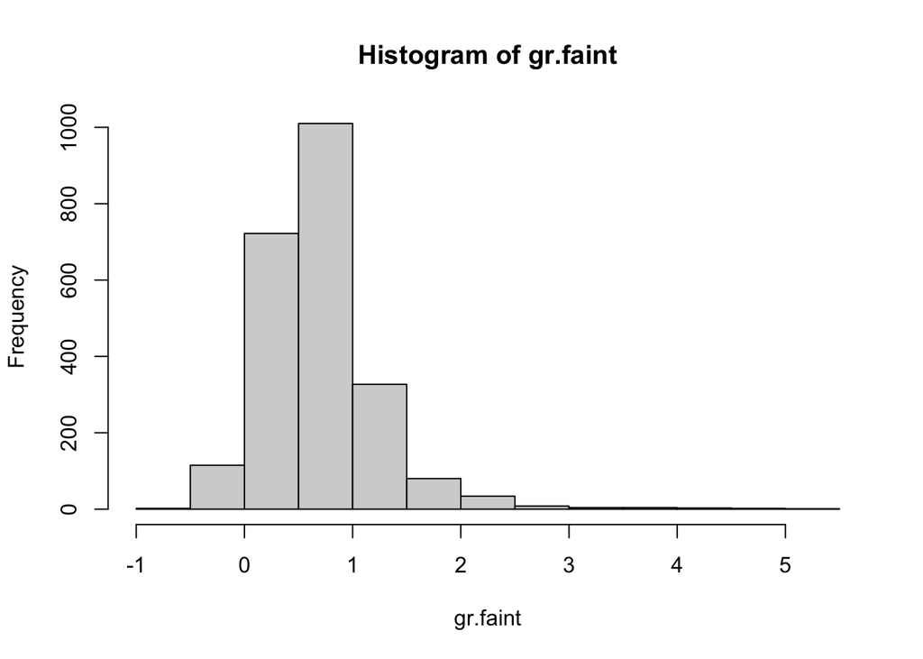

```r
# FILL ME IN
hist(gr.faint)
```

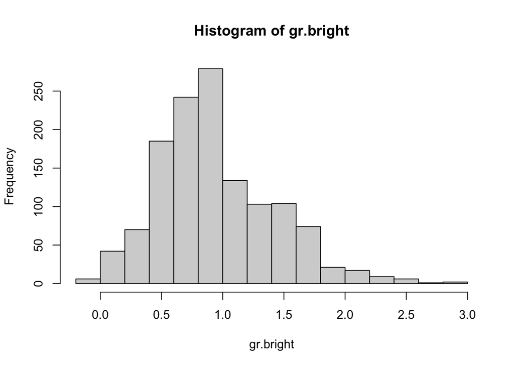

```r
hist(gr.bright)
```

```r
t.test(gr.bright,gr.faint)
```

```
##
##  Welch Two Sample t-test
##
## data:  gr.bright and gr.faint
## t = 14.389, df = 2979.8, p-value < 2.2e-16
## alternative hypothesis: true difference in means is not equal to 0
## 95 percent confidence interval:
##  0.2140635 0.2816093
## sample estimates:
## mean of x mean of y
## 0.9420480 0.6942116
```

```
FILL ME IN WITH WORDS
From the two sample t test we get that the population means are not same with 0.05 level of significance as the p-value$=2.2*10^{-16}<<0.025$.
Nevertheless, we shouldn't use t test here as the data of gr.bright and gr.faint are not normally distributed.
```